# Regression Model for Online News Popularity Using Python Take 4

### December 9, 2019

Template Credit: Adapted from a template made available by Dr. Jason Brownlee of Machine Learning Mastery. [https://machinelearningmastery.com/]

SUMMARY: The purpose of this project is to construct a predictive model using various machine learning algorithms and to document the end-to-end steps using a template. The Online News Popularity dataset is a regression situation where we are trying to predict the value of a continuous variable.

INTRODUCTION: This dataset summarizes a heterogeneous set of features about articles published by Mashable in a period of two years. The goal is to predict the article's popularity level in social networks. The dataset does not contain the original content, but some statistics associated with it. The original content can be publicly accessed and retrieved using the provided URLs.

The data source credit goes to K. Fernandes, P. Vinagre and P. Cortez. A Proactive Intelligent Decision Support System for Predicting the Popularity of Online News. Proceedings of the 17th EPIA 2015 - Portuguese Conference on Artificial Intelligence, September, Coimbra, Portugal, for making the dataset and benchmarking information available.

Dataset Used: Online News Popularity Data Set

Dataset ML Model: Regression with numerical attributes

Dataset Reference: https://archive.ics.uci.edu/ml/datasets/Online+News+Popularity

The project aims to touch on the following areas:

- Document a predictive modeling problem end-to-end.
- Explore data cleaning and transformation options
- Explore non-ensemble and ensemble algorithms for baseline model performance
- Explore algorithm tuning techniques for improving model performance

Any predictive modeling machine learning project genrally can be broken down into about six major tasks:

1. Prepare Environment
2. Summarize Data
3. Prepare Data
4. Model and Evaluate Algorithms
5. Improve Accuracy or Results
6. Finalize Model and Present Results

## Section 1 - Prepare Environment

### 1.a) Load libraries and modules

```python
# Set the warning message filter
import warnings
warnings.filterwarnings("ignore", category=FutureWarning)
warnings.filterwarnings("ignore", category=DeprecationWarning)
```

```python
# Set the random seed number for reproducible results
seedNum = 888
```

```python
import numpy as np
import pandas as pd
import matplotlib.pyplot as plt
import math
import os
import sys
import shutil
import urllib.request
import zipfile
import smtplib
import re
from datetime import datetime
from email.message import EmailMessage
from pandas.plotting import scatter_matrix
from sklearn import preprocessing
from sklearn.model_selection import train_test_split
from sklearn.model_selection import KFold
from sklearn.model_selection import StratifiedKFold
from sklearn.model_selection import cross_val_score
from sklearn.model_selection import GridSearchCV
from sklearn.metrics import mean_squared_error
from sklearn.metrics import r2_score
from sklearn.pipeline import Pipeline
from sklearn.feature_selection import RFE
from imblearn.over_sampling import SMOTE
from imblearn.combine import SMOTEENN
from imblearn.combine import SMOTETomek

from sklearn.linear_model import LinearRegression
from sklearn.linear_model import Ridge
from sklearn.linear_model import Lasso
from sklearn.linear_model import ElasticNet
from sklearn.tree import DecisionTreeRegressor
from sklearn.neighbors import KNeighborsRegressor
from sklearn.ensemble import RandomForestRegressor
from sklearn.ensemble import ExtraTreesRegressor
from sklearn.ensemble import GradientBoostingRegressor
from xgboost import XGBRegressor
```

### 1.b) Set up the controlling parameters and functions

```python
# Begin the timer for the script processing
startTimeScript = datetime.now()

# Set up the number of CPU cores available for multi-thread processing
n_jobs = -1

# Set up the flag to stop sending progress emails (setting to True will send status emails!)
notifyStatus = False

# Set the flag for splitting the dataset
splitDataset = True
splitPercentage = 0.25

# Set the number of folds for cross validation
n_folds = 10

# Set various default modeling parameters
scoring = 'neg_mean_squared_error'
```

```python
# Set up the email notification function
def email_notify(msg_text):
    sender = os.environ.get('MAIL_SENDER')
    receiver = os.environ.get('MAIL_RECEIVER')
    gateway = os.environ.get('SMTP_GATEWAY')
    smtpuser = os.environ.get('SMTP_USERNAME')
    password = os.environ.get('SMTP_PASSWORD')
    if sender==None or receiver==None or gateway==None or smtpuser==None or password==None:
        sys.exit("Incomplete email setup info. Script Processing Aborted!!!")
    msg = EmailMessage()
    msg.set_content(msg_text)
    msg['Subject'] = 'Notification from Python Regression Modeling Script'
    msg['From'] = sender
    msg['To'] = receiver
    server = smtplib.SMTP(gateway, 587)
    server.starttls()
    server.login(smtpuser, password)
    server.send_message(msg)
    server.quit()
```

```python
if (notifyStatus): email_notify("Library and Data Loading has begun! "+datetime.now().strftime('%a %B %d, %Y %I:%M:%S %p'))
```

### 1.c) Load dataset

```python
dataset_path = 'https://raw.githubusercontent.com/daines-analytics/datasets-public/master/online-news-popularity/OnlineNewsPopularity.csv'
Xy_original = pd.read_csv(dataset_path, sep=',', index_col=False)
Xy_original.columns = Xy_original.columns.str.replace(' ','')

# Take a peek at the dataframe after import
Xy_original.head(10)
```

|  | url | timedelta | n_tokens_title | n_tokens_content | n_unique_tokens | n_non_stop_words | n_non_stop_unique_tokens | num_hrefs | num_self_hrefs | num_imgs | ... | min_positive_polarity | max_positive_polarity | avg_negative_polarity | min_negative_polarity | max_negative_polarity | title_subjectivity | title_sentiment_polarity | abs_title_subjectivity | abs_title_sentiment_polarity | shares |
| --- | --- | --- | --- | --- | --- | --- | --- | --- | --- | --- | --- | --- | --- | --- | --- | --- | --- | --- | --- | --- | --- |
| 0 | http://mashable.com/2013/01/07/amazon-instant-... | 731.0 | 12.0 | 219.0 | 0.663594 | 1.0 | 0.815385 | 4.0 | 2.0 | 1.0 | ... | 0.100000 | 0.7 | -0.350000 | -0.600 | -0.200000 | 0.500000 | -0.187500 | 0.000000 | 0.187500 | 593 |
| 1 | http://mashable.com/2013/01/07/ap-samsung-spon... | 731.0 | 9.0 | 255.0 | 0.604743 | 1.0 | 0.791946 | 3.0 | 1.0 | 1.0 | ... | 0.033333 | 0.7 | -0.118750 | -0.125 | -0.100000 | 0.000000 | 0.000000 | 0.500000 | 0.000000 | 711 |
| 2 | http://mashable.com/2013/01/07/apple-40-billio... | 731.0 | 9.0 | 211.0 | 0.575130 | 1.0 | 0.663866 | 3.0 | 1.0 | 1.0 | ... | 0.100000 | 1.0 | -0.466667 | -0.800 | -0.133333 | 0.000000 | 0.000000 | 0.500000 | 0.000000 | 1500 |
| 3 | http://mashable.com/2013/01/07/astronaut-notre... | 731.0 | 9.0 | 531.0 | 0.503788 | 1.0 | 0.665635 | 9.0 | 0.0 | 1.0 | ... | 0.136364 | 0.8 | -0.369697 | -0.600 | -0.166667 | 0.000000 | 0.000000 | 0.500000 | 0.000000 | 1200 |
| 4 | http://mashable.com/2013/01/07/att-u-verse-apps/ | 731.0 | 13.0 | 1072.0 | 0.415646 | 1.0 | 0.540890 | 19.0 | 19.0 | 20.0 | ... | 0.033333 | 1.0 | -0.220192 | -0.500 | -0.050000 | 0.454545 | 0.136364 | 0.045455 | 0.136364 | 505 |
| 5 | http://mashable.com/2013/01/07/beewi-smart-toys/ | 731.0 | 10.0 | 370.0 | 0.559889 | 1.0 | 0.698198 | 2.0 | 2.0 | 0.0 | ... | 0.136364 | 0.6 | -0.195000 | -0.400 | -0.100000 | 0.642857 | 0.214286 | 0.142857 | 0.214286 | 855 |
| 6 | http://mashable.com/2013/01/07/bodymedia-armba... | 731.0 | 8.0 | 960.0 | 0.418163 | 1.0 | 0.549834 | 21.0 | 20.0 | 20.0 | ... | 0.100000 | 1.0 | -0.224479 | -0.500 | -0.050000 | 0.000000 | 0.000000 | 0.500000 | 0.000000 | 556 |
| 7 | http://mashable.com/2013/01/07/canon-poweshot-n/ | 731.0 | 12.0 | 989.0 | 0.433574 | 1.0 | 0.572108 | 20.0 | 20.0 | 20.0 | ... | 0.100000 | 1.0 | -0.242778 | -0.500 | -0.050000 | 1.000000 | 0.500000 | 0.500000 | 0.500000 | 891 |
| 8 | http://mashable.com/2013/01/07/car-of-the-futu... | 731.0 | 11.0 | 97.0 | 0.670103 | 1.0 | 0.836735 | 2.0 | 0.0 | 0.0 | ... | 0.400000 | 0.8 | -0.125000 | -0.125 | -0.125000 | 0.125000 | 0.000000 | 0.375000 | 0.000000 | 3600 |
| 9 | http://mashable.com/2013/01/07/chuck-hagel-web... | 731.0 | 10.0 | 231.0 | 0.636364 | 1.0 | 0.797101 | 4.0 | 1.0 | 1.0 | ... | 0.100000 | 0.5 | -0.238095 | -0.500 | -0.100000 | 0.000000 | 0.000000 | 0.500000 | 0.000000 | 710 |

10 rows × 61 columns

```python
Xy_original.info()
```

```
<class 'pandas.core.frame.DataFrame'>
RangeIndex: 39644 entries, 0 to 39643
Data columns (total 61 columns):
url                              39644 non-null object
timedelta                        39644 non-null float64
n_tokens_title                   39644 non-null float64
n_tokens_content                 39644 non-null float64
n_unique_tokens                  39644 non-null float64
n_non_stop_words                 39644 non-null float64
n_non_stop_unique_tokens         39644 non-null float64
num_hrefs                        39644 non-null float64
num_self_hrefs                   39644 non-null float64
num_imgs                         39644 non-null float64
num_videos                       39644 non-null float64
average_token_length             39644 non-null float64
num_keywords                     39644 non-null float64
data_channel_is_lifestyle        39644 non-null float64
data_channel_is_entertainment    39644 non-null float64
data_channel_is_bus              39644 non-null float64
data_channel_is_socmed           39644 non-null float64
data_channel_is_tech             39644 non-null float64
data_channel_is_world            39644 non-null float64
kw_min_min                       39644 non-null float64
kw_max_min                       39644 non-null float64
kw_avg_min                       39644 non-null float64
kw_min_max                       39644 non-null float64
kw_max_max                       39644 non-null float64
kw_avg_max                       39644 non-null float64
kw_min_avg                       39644 non-null float64
kw_max_avg                       39644 non-null float64
kw_avg_avg                       39644 non-null float64
self_reference_min_shares        39644 non-null float64
self_reference_max_shares        39644 non-null float64
self_reference_avg_sharess       39644 non-null float64
weekday_is_monday                39644 non-null float64
weekday_is_tuesday               39644 non-null float64
weekday_is_wednesday             39644 non-null float64
weekday_is_thursday              39644 non-null float64
weekday_is_friday                39644 non-null float64
weekday_is_saturday              39644 non-null float64
```

[output cut: 11 more lines]

```
rate_positive_words              39644 non-null float64
rate_negative_words              39644 non-null float64
avg_positive_polarity            39644 non-null float64
min_positive_polarity            39644 non-null float64
max_positive_polarity            39644 non-null float64
avg_negative_polarity            39644 non-null float64
min_negative_polarity            39644 non-null float64
max_negative_polarity            39644 non-null float64
title_subjectivity               39644 non-null float64
title_sentiment_polarity         39644 non-null float64
abs_title_subjectivity           39644 non-null float64
abs_title_sentiment_polarity     39644 non-null float64
shares                           39644 non-null int64
dtypes: float64(59), int64(1), object(1)
memory usage: 18.5+ MB
```

```python
Xy_original.describe()
```

|  | timedelta | n_tokens_title | n_tokens_content | n_unique_tokens | n_non_stop_words | n_non_stop_unique_tokens | num_hrefs | num_self_hrefs | num_imgs | num_videos | ... | min_positive_polarity | max_positive_polarity | avg_negative_polarity | min_negative_polarity | max_negative_polarity | title_subjectivity | title_sentiment_polarity | abs_title_subjectivity | abs_title_sentiment_polarity | shares |
| --- | --- | --- | --- | --- | --- | --- | --- | --- | --- | --- | --- | --- | --- | --- | --- | --- | --- | --- | --- | --- | --- |
| count | 39644.000000 | 39644.000000 | 39644.000000 | 39644.000000 | 39644.000000 | 39644.000000 | 39644.000000 | 39644.000000 | 39644.000000 | 39644.000000 | ... | 39644.000000 | 39644.000000 | 39644.000000 | 39644.000000 | 39644.000000 | 39644.000000 | 39644.000000 | 39644.000000 | 39644.000000 | 39644.000000 |
| mean | 354.530471 | 10.398749 | 546.514731 | 0.548216 | 0.996469 | 0.689175 | 10.883690 | 3.293638 | 4.544143 | 1.249874 | ... | 0.095446 | 0.756728 | -0.259524 | -0.521944 | -0.107500 | 0.282353 | 0.071425 | 0.341843 | 0.156064 | 3395.380184 |
| std | 214.163767 | 2.114037 | 471.107508 | 3.520708 | 5.231231 | 3.264816 | 11.332017 | 3.855141 | 8.309434 | 4.107855 | ... | 0.071315 | 0.247786 | 0.127726 | 0.290290 | 0.095373 | 0.324247 | 0.265450 | 0.188791 | 0.226294 | 11626.950749 |
| min | 8.000000 | 2.000000 | 0.000000 | 0.000000 | 0.000000 | 0.000000 | 0.000000 | 0.000000 | 0.000000 | 0.000000 | ... | 0.000000 | 0.000000 | -1.000000 | -1.000000 | -1.000000 | 0.000000 | -1.000000 | 0.000000 | 0.000000 | 1.000000 |
| 25% | 164.000000 | 9.000000 | 246.000000 | 0.470870 | 1.000000 | 0.625739 | 4.000000 | 1.000000 | 1.000000 | 0.000000 | ... | 0.050000 | 0.600000 | -0.328383 | -0.700000 | -0.125000 | 0.000000 | 0.000000 | 0.166667 | 0.000000 | 946.000000 |
| 50% | 339.000000 | 10.000000 | 409.000000 | 0.539226 | 1.000000 | 0.690476 | 8.000000 | 3.000000 | 1.000000 | 0.000000 | ... | 0.100000 | 0.800000 | -0.253333 | -0.500000 | -0.100000 | 0.150000 | 0.000000 | 0.500000 | 0.000000 | 1400.000000 |
| 75% | 542.000000 | 12.000000 | 716.000000 | 0.608696 | 1.000000 | 0.754630 | 14.000000 | 4.000000 | 4.000000 | 1.000000 | ... | 0.100000 | 1.000000 | -0.186905 | -0.300000 | -0.050000 | 0.500000 | 0.150000 | 0.500000 | 0.250000 | 2800.000000 |
| max | 731.000000 | 23.000000 | 8474.000000 | 701.000000 | 1042.000000 | 650.000000 | 304.000000 | 116.000000 | 128.000000 | 91.000000 | ... | 1.000000 | 1.000000 | 0.000000 | 0.000000 | 0.000000 | 1.000000 | 1.000000 | 0.500000 | 1.000000 | 843300.000000 |

8 rows × 60 columns

```python
print(Xy_original.isnull().sum())
print('Total number of NaN in the dataframe: ', Xy_original.isnull().sum().sum())
```

```
url                             0
timedelta                       0
n_tokens_title                  0
n_tokens_content                0
n_unique_tokens                 0
                               ..
title_subjectivity              0
title_sentiment_polarity        0
abs_title_subjectivity          0
abs_title_sentiment_polarity    0
shares                          0
Length: 61, dtype: int64
Total number of NaN in the dataframe:  0
```

### 1.d) Data Cleaning

```python
# Standardize the class column to the name of targetVar if required
Xy_original = Xy_original.rename(columns={'shares': 'targetVar'})

# Dropping features
Xy_original.drop(columns=['url','timedelta'], inplace=True)

# Convert columns from one data type to another
Xy_original.data_channel_is_lifestyle = Xy_original.data_channel_is_lifestyle.astype('int')
Xy_original.data_channel_is_entertainment = Xy_original.data_channel_is_entertainment.astype('int')
Xy_original.data_channel_is_bus = Xy_original.data_channel_is_bus.astype('int')
Xy_original.data_channel_is_socmed = Xy_original.data_channel_is_socmed.astype('int')
Xy_original.data_channel_is_tech = Xy_original.data_channel_is_tech.astype('int')
Xy_original.data_channel_is_world = Xy_original.data_channel_is_world.astype('int')
Xy_original.weekday_is_monday = Xy_original.weekday_is_monday.astype('int')
Xy_original.weekday_is_tuesday = Xy_original.weekday_is_tuesday.astype('int')
Xy_original.weekday_is_wednesday = Xy_original.weekday_is_wednesday.astype('int')
Xy_original.weekday_is_thursday = Xy_original.weekday_is_thursday.astype('int')
Xy_original.weekday_is_friday = Xy_original.weekday_is_friday.astype('int')
Xy_original.weekday_is_saturday = Xy_original.weekday_is_saturday.astype('int')
Xy_original.weekday_is_sunday = Xy_original.weekday_is_sunday.astype('int')
Xy_original.is_weekend = Xy_original.is_weekend.astype('int')

# Take a peek at the dataframe after cleaning
Xy_original.head(10)
```

|  | n_tokens_title | n_tokens_content | n_unique_tokens | n_non_stop_words | n_non_stop_unique_tokens | num_hrefs | num_self_hrefs | num_imgs | num_videos | average_token_length | ... | min_positive_polarity | max_positive_polarity | avg_negative_polarity | min_negative_polarity | max_negative_polarity | title_subjectivity | title_sentiment_polarity | abs_title_subjectivity | abs_title_sentiment_polarity | targetVar |
| --- | --- | --- | --- | --- | --- | --- | --- | --- | --- | --- | --- | --- | --- | --- | --- | --- | --- | --- | --- | --- | --- |
| 0 | 12.0 | 219.0 | 0.663594 | 1.0 | 0.815385 | 4.0 | 2.0 | 1.0 | 0.0 | 4.680365 | ... | 0.100000 | 0.7 | -0.350000 | -0.600 | -0.200000 | 0.500000 | -0.187500 | 0.000000 | 0.187500 | 593 |
| 1 | 9.0 | 255.0 | 0.604743 | 1.0 | 0.791946 | 3.0 | 1.0 | 1.0 | 0.0 | 4.913725 | ... | 0.033333 | 0.7 | -0.118750 | -0.125 | -0.100000 | 0.000000 | 0.000000 | 0.500000 | 0.000000 | 711 |
| 2 | 9.0 | 211.0 | 0.575130 | 1.0 | 0.663866 | 3.0 | 1.0 | 1.0 | 0.0 | 4.393365 | ... | 0.100000 | 1.0 | -0.466667 | -0.800 | -0.133333 | 0.000000 | 0.000000 | 0.500000 | 0.000000 | 1500 |
| 3 | 9.0 | 531.0 | 0.503788 | 1.0 | 0.665635 | 9.0 | 0.0 | 1.0 | 0.0 | 4.404896 | ... | 0.136364 | 0.8 | -0.369697 | -0.600 | -0.166667 | 0.000000 | 0.000000 | 0.500000 | 0.000000 | 1200 |
| 4 | 13.0 | 1072.0 | 0.415646 | 1.0 | 0.540890 | 19.0 | 19.0 | 20.0 | 0.0 | 4.682836 | ... | 0.033333 | 1.0 | -0.220192 | -0.500 | -0.050000 | 0.454545 | 0.136364 | 0.045455 | 0.136364 | 505 |
| 5 | 10.0 | 370.0 | 0.559889 | 1.0 | 0.698198 | 2.0 | 2.0 | 0.0 | 0.0 | 4.359459 | ... | 0.136364 | 0.6 | -0.195000 | -0.400 | -0.100000 | 0.642857 | 0.214286 | 0.142857 | 0.214286 | 855 |
| 6 | 8.0 | 960.0 | 0.418163 | 1.0 | 0.549834 | 21.0 | 20.0 | 20.0 | 0.0 | 4.654167 | ... | 0.100000 | 1.0 | -0.224479 | -0.500 | -0.050000 | 0.000000 | 0.000000 | 0.500000 | 0.000000 | 556 |
| 7 | 12.0 | 989.0 | 0.433574 | 1.0 | 0.572108 | 20.0 | 20.0 | 20.0 | 0.0 | 4.617796 | ... | 0.100000 | 1.0 | -0.242778 | -0.500 | -0.050000 | 1.000000 | 0.500000 | 0.500000 | 0.500000 | 891 |
| 8 | 11.0 | 97.0 | 0.670103 | 1.0 | 0.836735 | 2.0 | 0.0 | 0.0 | 0.0 | 4.855670 | ... | 0.400000 | 0.8 | -0.125000 | -0.125 | -0.125000 | 0.125000 | 0.000000 | 0.375000 | 0.000000 | 3600 |
| 9 | 10.0 | 231.0 | 0.636364 | 1.0 | 0.797101 | 4.0 | 1.0 | 1.0 | 1.0 | 5.090909 | ... | 0.100000 | 0.5 | -0.238095 | -0.500 | -0.100000 | 0.000000 | 0.000000 | 0.500000 | 0.000000 | 710 |

10 rows × 59 columns

```python
Xy_original.info()
```

```
<class 'pandas.core.frame.DataFrame'>
RangeIndex: 39644 entries, 0 to 39643
Data columns (total 59 columns):
n_tokens_title                   39644 non-null float64
n_tokens_content                 39644 non-null float64
n_unique_tokens                  39644 non-null float64
n_non_stop_words                 39644 non-null float64
n_non_stop_unique_tokens         39644 non-null float64
num_hrefs                        39644 non-null float64
num_self_hrefs                   39644 non-null float64
num_imgs                         39644 non-null float64
num_videos                       39644 non-null float64
average_token_length             39644 non-null float64
num_keywords                     39644 non-null float64
data_channel_is_lifestyle        39644 non-null int64
data_channel_is_entertainment    39644 non-null int64
data_channel_is_bus              39644 non-null int64
data_channel_is_socmed           39644 non-null int64
data_channel_is_tech             39644 non-null int64
data_channel_is_world            39644 non-null int64
kw_min_min                       39644 non-null float64
kw_max_min                       39644 non-null float64
kw_avg_min                       39644 non-null float64
kw_min_max                       39644 non-null float64
kw_max_max                       39644 non-null float64
kw_avg_max                       39644 non-null float64
kw_min_avg                       39644 non-null float64
kw_max_avg                       39644 non-null float64
kw_avg_avg                       39644 non-null float64
self_reference_min_shares        39644 non-null float64
self_reference_max_shares        39644 non-null float64
self_reference_avg_sharess       39644 non-null float64
weekday_is_monday                39644 non-null int64
weekday_is_tuesday               39644 non-null int64
weekday_is_wednesday             39644 non-null int64
weekday_is_thursday              39644 non-null int64
weekday_is_friday                39644 non-null int64
weekday_is_saturday              39644 non-null int64
weekday_is_sunday                39644 non-null int64
is_weekend                       39644 non-null int64
```

[output cut: 9 more lines]

```
rate_positive_words              39644 non-null float64
rate_negative_words              39644 non-null float64
avg_positive_polarity            39644 non-null float64
min_positive_polarity            39644 non-null float64
max_positive_polarity            39644 non-null float64
avg_negative_polarity            39644 non-null float64
min_negative_polarity            39644 non-null float64
max_negative_polarity            39644 non-null float64
title_subjectivity               39644 non-null float64
title_sentiment_polarity         39644 non-null float64
abs_title_subjectivity           39644 non-null float64
abs_title_sentiment_polarity     39644 non-null float64
targetVar                        39644 non-null int64
dtypes: float64(44), int64(15)
memory usage: 17.8 MB
```

```python
Xy_original.describe()
```

|  | n_tokens_title | n_tokens_content | n_unique_tokens | n_non_stop_words | n_non_stop_unique_tokens | num_hrefs | num_self_hrefs | num_imgs | num_videos | average_token_length | ... | min_positive_polarity | max_positive_polarity | avg_negative_polarity | min_negative_polarity | max_negative_polarity | title_subjectivity | title_sentiment_polarity | abs_title_subjectivity | abs_title_sentiment_polarity | targetVar |
| --- | --- | --- | --- | --- | --- | --- | --- | --- | --- | --- | --- | --- | --- | --- | --- | --- | --- | --- | --- | --- | --- |
| count | 39644.000000 | 39644.000000 | 39644.000000 | 39644.000000 | 39644.000000 | 39644.000000 | 39644.000000 | 39644.000000 | 39644.000000 | 39644.000000 | ... | 39644.000000 | 39644.000000 | 39644.000000 | 39644.000000 | 39644.000000 | 39644.000000 | 39644.000000 | 39644.000000 | 39644.000000 | 39644.000000 |
| mean | 10.398749 | 546.514731 | 0.548216 | 0.996469 | 0.689175 | 10.883690 | 3.293638 | 4.544143 | 1.249874 | 4.548239 | ... | 0.095446 | 0.756728 | -0.259524 | -0.521944 | -0.107500 | 0.282353 | 0.071425 | 0.341843 | 0.156064 | 3395.380184 |
| std | 2.114037 | 471.107508 | 3.520708 | 5.231231 | 3.264816 | 11.332017 | 3.855141 | 8.309434 | 4.107855 | 0.844406 | ... | 0.071315 | 0.247786 | 0.127726 | 0.290290 | 0.095373 | 0.324247 | 0.265450 | 0.188791 | 0.226294 | 11626.950749 |
| min | 2.000000 | 0.000000 | 0.000000 | 0.000000 | 0.000000 | 0.000000 | 0.000000 | 0.000000 | 0.000000 | 0.000000 | ... | 0.000000 | 0.000000 | -1.000000 | -1.000000 | -1.000000 | 0.000000 | -1.000000 | 0.000000 | 0.000000 | 1.000000 |
| 25% | 9.000000 | 246.000000 | 0.470870 | 1.000000 | 0.625739 | 4.000000 | 1.000000 | 1.000000 | 0.000000 | 4.478404 | ... | 0.050000 | 0.600000 | -0.328383 | -0.700000 | -0.125000 | 0.000000 | 0.000000 | 0.166667 | 0.000000 | 946.000000 |
| 50% | 10.000000 | 409.000000 | 0.539226 | 1.000000 | 0.690476 | 8.000000 | 3.000000 | 1.000000 | 0.000000 | 4.664082 | ... | 0.100000 | 0.800000 | -0.253333 | -0.500000 | -0.100000 | 0.150000 | 0.000000 | 0.500000 | 0.000000 | 1400.000000 |
| 75% | 12.000000 | 716.000000 | 0.608696 | 1.000000 | 0.754630 | 14.000000 | 4.000000 | 4.000000 | 1.000000 | 4.854839 | ... | 0.100000 | 1.000000 | -0.186905 | -0.300000 | -0.050000 | 0.500000 | 0.150000 | 0.500000 | 0.250000 | 2800.000000 |
| max | 23.000000 | 8474.000000 | 701.000000 | 1042.000000 | 650.000000 | 304.000000 | 116.000000 | 128.000000 | 91.000000 | 8.041534 | ... | 1.000000 | 1.000000 | 0.000000 | 0.000000 | 0.000000 | 1.000000 | 1.000000 | 0.500000 | 1.000000 | 843300.000000 |

8 rows × 59 columns

```python
print(Xy_original.isnull().sum())
print('Total number of NaN in the dataframe: ', Xy_original.isnull().sum().sum())
```

```
n_tokens_title                   0
n_tokens_content                 0
n_unique_tokens                  0
n_non_stop_words                 0
n_non_stop_unique_tokens         0
num_hrefs                        0
num_self_hrefs                   0
num_imgs                         0
num_videos                       0
average_token_length             0
num_keywords                     0
data_channel_is_lifestyle        0
data_channel_is_entertainment    0
data_channel_is_bus              0
data_channel_is_socmed           0
data_channel_is_tech             0
data_channel_is_world            0
kw_min_min                       0
kw_max_min                       0
kw_avg_min                       0
kw_min_max                       0
kw_max_max                       0
kw_avg_max                       0
kw_min_avg                       0
kw_max_avg                       0
kw_avg_avg                       0
self_reference_min_shares        0
self_reference_max_shares        0
self_reference_avg_sharess       0
weekday_is_monday                0
weekday_is_tuesday               0
weekday_is_wednesday             0
weekday_is_thursday              0
weekday_is_friday                0
weekday_is_saturday              0
weekday_is_sunday                0
is_weekend                       0
LDA_00                           0
LDA_01                           0
LDA_02                           0
LDA_03                           0
LDA_04                           0
global_subjectivity              0
global_sentiment_polarity        0
global_rate_positive_words       0
global_rate_negative_words       0
rate_positive_words              0
rate_negative_words              0
avg_positive_polarity            0
min_positive_polarity            0
max_positive_polarity            0
avg_negative_polarity            0
min_negative_polarity            0
max_negative_polarity            0
title_subjectivity               0
title_sentiment_polarity         0
abs_title_subjectivity           0
abs_title_sentiment_polarity     0
targetVar                        0
dtype: int64
Total number of NaN in the dataframe:  0
```

### 1.e) Splitting Data into Attribute-only and Target-only Sets

```python
# Use variable totCol to hold the number of columns in the dataframe
totCol = len(Xy_original.columns)

# Set up variable totAttr for the total number of attribute columns
totAttr = totCol-1

# targetCol variable indicates the column location of the target/class variable
# If the first column, set targetCol to 1. If the last column, set targetCol to totCol
# If (targetCol <> 1) and (targetCol <> totCol), be aware when slicing up the dataframes for visualization
targetCol = totCol
```

```python
# We create attribute-only and target-only datasets (X_original and y_original)
# for various visualization and cleaning/transformation operations

if targetCol == totCol:
    X_original = Xy_original.iloc[:,0:totAttr]
    y_original = Xy_original.iloc[:,totAttr]
else:
    X_original = Xy_original.iloc[:,1:totCol]
    y_original = Xy_original.iloc[:,0]

print("Xy_original.shape: {} X_original.shape: {} y_original.shape: {}".format(Xy_original.shape, X_original.shape, y_original.shape))
```

```
Xy_original.shape: (39644, 59) X_original.shape: (39644, 58) y_original.shape: (39644,)
```

### 1.f) Set up the parameters for data visualization

```python
# Set up the number of row and columns for visualization display. dispRow * dispCol should be >= totAttr
dispCol = 4
if totAttr % dispCol == 0 :
    dispRow = totAttr // dispCol
else :
    dispRow = (totAttr // dispCol) + 1

# Set figure width to display the data visualization plots
fig_size = plt.rcParams["figure.figsize"]
fig_size[0] = dispCol*4
fig_size[1] = dispRow*4
plt.rcParams["figure.figsize"] = fig_size
```

```python
if (notifyStatus): email_notify("Library and Data Loading completed! "+datetime.now().strftime('%a %B %d, %Y %I:%M:%S %p'))
```

## Section 2 - Summarize Data

To gain a better understanding of the data that we have on-hand, we will leverage a number of descriptive statistics and data visualization techniques. The plan is to use the results to consider new questions, review assumptions, and validate hypotheses that we can investigate later with specialized models.

```python
if (notifyStatus): email_notify("Data Summarization and Visualization has begun! "+datetime.now().strftime('%a %B %d, %Y %I:%M:%S %p'))
```

### 2.a) Descriptive Statistics

#### 2.a.i) Peek at the attribute columns

```python
X_original.head(10)
```

|  | n_tokens_title | n_tokens_content | n_unique_tokens | n_non_stop_words | n_non_stop_unique_tokens | num_hrefs | num_self_hrefs | num_imgs | num_videos | average_token_length | ... | avg_positive_polarity | min_positive_polarity | max_positive_polarity | avg_negative_polarity | min_negative_polarity | max_negative_polarity | title_subjectivity | title_sentiment_polarity | abs_title_subjectivity | abs_title_sentiment_polarity |
| --- | --- | --- | --- | --- | --- | --- | --- | --- | --- | --- | --- | --- | --- | --- | --- | --- | --- | --- | --- | --- | --- |
| 0 | 12.0 | 219.0 | 0.663594 | 1.0 | 0.815385 | 4.0 | 2.0 | 1.0 | 0.0 | 4.680365 | ... | 0.378636 | 0.100000 | 0.7 | -0.350000 | -0.600 | -0.200000 | 0.500000 | -0.187500 | 0.000000 | 0.187500 |
| 1 | 9.0 | 255.0 | 0.604743 | 1.0 | 0.791946 | 3.0 | 1.0 | 1.0 | 0.0 | 4.913725 | ... | 0.286915 | 0.033333 | 0.7 | -0.118750 | -0.125 | -0.100000 | 0.000000 | 0.000000 | 0.500000 | 0.000000 |
| 2 | 9.0 | 211.0 | 0.575130 | 1.0 | 0.663866 | 3.0 | 1.0 | 1.0 | 0.0 | 4.393365 | ... | 0.495833 | 0.100000 | 1.0 | -0.466667 | -0.800 | -0.133333 | 0.000000 | 0.000000 | 0.500000 | 0.000000 |
| 3 | 9.0 | 531.0 | 0.503788 | 1.0 | 0.665635 | 9.0 | 0.0 | 1.0 | 0.0 | 4.404896 | ... | 0.385965 | 0.136364 | 0.8 | -0.369697 | -0.600 | -0.166667 | 0.000000 | 0.000000 | 0.500000 | 0.000000 |
| 4 | 13.0 | 1072.0 | 0.415646 | 1.0 | 0.540890 | 19.0 | 19.0 | 20.0 | 0.0 | 4.682836 | ... | 0.411127 | 0.033333 | 1.0 | -0.220192 | -0.500 | -0.050000 | 0.454545 | 0.136364 | 0.045455 | 0.136364 |
| 5 | 10.0 | 370.0 | 0.559889 | 1.0 | 0.698198 | 2.0 | 2.0 | 0.0 | 0.0 | 4.359459 | ... | 0.350610 | 0.136364 | 0.6 | -0.195000 | -0.400 | -0.100000 | 0.642857 | 0.214286 | 0.142857 | 0.214286 |
| 6 | 8.0 | 960.0 | 0.418163 | 1.0 | 0.549834 | 21.0 | 20.0 | 20.0 | 0.0 | 4.654167 | ... | 0.402039 | 0.100000 | 1.0 | -0.224479 | -0.500 | -0.050000 | 0.000000 | 0.000000 | 0.500000 | 0.000000 |
| 7 | 12.0 | 989.0 | 0.433574 | 1.0 | 0.572108 | 20.0 | 20.0 | 20.0 | 0.0 | 4.617796 | ... | 0.427720 | 0.100000 | 1.0 | -0.242778 | -0.500 | -0.050000 | 1.000000 | 0.500000 | 0.500000 | 0.500000 |
| 8 | 11.0 | 97.0 | 0.670103 | 1.0 | 0.836735 | 2.0 | 0.0 | 0.0 | 0.0 | 4.855670 | ... | 0.566667 | 0.400000 | 0.8 | -0.125000 | -0.125 | -0.125000 | 0.125000 | 0.000000 | 0.375000 | 0.000000 |
| 9 | 10.0 | 231.0 | 0.636364 | 1.0 | 0.797101 | 4.0 | 1.0 | 1.0 | 1.0 | 5.090909 | ... | 0.298413 | 0.100000 | 0.5 | -0.238095 | -0.500 | -0.100000 | 0.000000 | 0.000000 | 0.500000 | 0.000000 |

10 rows × 58 columns

#### 2.a.ii) Dimensions and attribute types

```python
X_original.info()
```

```
<class 'pandas.core.frame.DataFrame'>
RangeIndex: 39644 entries, 0 to 39643
Data columns (total 58 columns):
n_tokens_title                   39644 non-null float64
n_tokens_content                 39644 non-null float64
n_unique_tokens                  39644 non-null float64
n_non_stop_words                 39644 non-null float64
n_non_stop_unique_tokens         39644 non-null float64
num_hrefs                        39644 non-null float64
num_self_hrefs                   39644 non-null float64
num_imgs                         39644 non-null float64
num_videos                       39644 non-null float64
average_token_length             39644 non-null float64
num_keywords                     39644 non-null float64
data_channel_is_lifestyle        39644 non-null int64
data_channel_is_entertainment    39644 non-null int64
data_channel_is_bus              39644 non-null int64
data_channel_is_socmed           39644 non-null int64
data_channel_is_tech             39644 non-null int64
data_channel_is_world            39644 non-null int64
kw_min_min                       39644 non-null float64
kw_max_min                       39644 non-null float64
kw_avg_min                       39644 non-null float64
kw_min_max                       39644 non-null float64
kw_max_max                       39644 non-null float64
kw_avg_max                       39644 non-null float64
kw_min_avg                       39644 non-null float64
kw_max_avg                       39644 non-null float64
kw_avg_avg                       39644 non-null float64
self_reference_min_shares        39644 non-null float64
self_reference_max_shares        39644 non-null float64
self_reference_avg_sharess       39644 non-null float64
weekday_is_monday                39644 non-null int64
weekday_is_tuesday               39644 non-null int64
weekday_is_wednesday             39644 non-null int64
weekday_is_thursday              39644 non-null int64
weekday_is_friday                39644 non-null int64
weekday_is_saturday              39644 non-null int64
weekday_is_sunday                39644 non-null int64
is_weekend                       39644 non-null int64
```

[output cut: 8 more lines]

```
global_rate_negative_words       39644 non-null float64
rate_positive_words              39644 non-null float64
rate_negative_words              39644 non-null float64
avg_positive_polarity            39644 non-null float64
min_positive_polarity            39644 non-null float64
max_positive_polarity            39644 non-null float64
avg_negative_polarity            39644 non-null float64
min_negative_polarity            39644 non-null float64
max_negative_polarity            39644 non-null float64
title_subjectivity               39644 non-null float64
title_sentiment_polarity         39644 non-null float64
abs_title_subjectivity           39644 non-null float64
abs_title_sentiment_polarity     39644 non-null float64
dtypes: float64(44), int64(14)
memory usage: 17.5 MB
```

#### 2.a.iii) Statistical summary of the attributes

```python
X_original.describe()
```

|  | n_tokens_title | n_tokens_content | n_unique_tokens | n_non_stop_words | n_non_stop_unique_tokens | num_hrefs | num_self_hrefs | num_imgs | num_videos | average_token_length | ... | avg_positive_polarity | min_positive_polarity | max_positive_polarity | avg_negative_polarity | min_negative_polarity | max_negative_polarity | title_subjectivity | title_sentiment_polarity | abs_title_subjectivity | abs_title_sentiment_polarity |
| --- | --- | --- | --- | --- | --- | --- | --- | --- | --- | --- | --- | --- | --- | --- | --- | --- | --- | --- | --- | --- | --- |
| count | 39644.000000 | 39644.000000 | 39644.000000 | 39644.000000 | 39644.000000 | 39644.000000 | 39644.000000 | 39644.000000 | 39644.000000 | 39644.000000 | ... | 39644.000000 | 39644.000000 | 39644.000000 | 39644.000000 | 39644.000000 | 39644.000000 | 39644.000000 | 39644.000000 | 39644.000000 | 39644.000000 |
| mean | 10.398749 | 546.514731 | 0.548216 | 0.996469 | 0.689175 | 10.883690 | 3.293638 | 4.544143 | 1.249874 | 4.548239 | ... | 0.353825 | 0.095446 | 0.756728 | -0.259524 | -0.521944 | -0.107500 | 0.282353 | 0.071425 | 0.341843 | 0.156064 |
| std | 2.114037 | 471.107508 | 3.520708 | 5.231231 | 3.264816 | 11.332017 | 3.855141 | 8.309434 | 4.107855 | 0.844406 | ... | 0.104542 | 0.071315 | 0.247786 | 0.127726 | 0.290290 | 0.095373 | 0.324247 | 0.265450 | 0.188791 | 0.226294 |
| min | 2.000000 | 0.000000 | 0.000000 | 0.000000 | 0.000000 | 0.000000 | 0.000000 | 0.000000 | 0.000000 | 0.000000 | ... | 0.000000 | 0.000000 | 0.000000 | -1.000000 | -1.000000 | -1.000000 | 0.000000 | -1.000000 | 0.000000 | 0.000000 |
| 25% | 9.000000 | 246.000000 | 0.470870 | 1.000000 | 0.625739 | 4.000000 | 1.000000 | 1.000000 | 0.000000 | 4.478404 | ... | 0.306244 | 0.050000 | 0.600000 | -0.328383 | -0.700000 | -0.125000 | 0.000000 | 0.000000 | 0.166667 | 0.000000 |
| 50% | 10.000000 | 409.000000 | 0.539226 | 1.000000 | 0.690476 | 8.000000 | 3.000000 | 1.000000 | 0.000000 | 4.664082 | ... | 0.358755 | 0.100000 | 0.800000 | -0.253333 | -0.500000 | -0.100000 | 0.150000 | 0.000000 | 0.500000 | 0.000000 |
| 75% | 12.000000 | 716.000000 | 0.608696 | 1.000000 | 0.754630 | 14.000000 | 4.000000 | 4.000000 | 1.000000 | 4.854839 | ... | 0.411428 | 0.100000 | 1.000000 | -0.186905 | -0.300000 | -0.050000 | 0.500000 | 0.150000 | 0.500000 | 0.250000 |
| max | 23.000000 | 8474.000000 | 701.000000 | 1042.000000 | 650.000000 | 304.000000 | 116.000000 | 128.000000 | 91.000000 | 8.041534 | ... | 1.000000 | 1.000000 | 1.000000 | 0.000000 | 0.000000 | 0.000000 | 1.000000 | 1.000000 | 0.500000 | 1.000000 |

8 rows × 58 columns

### 2.b) Data Visualization

##### 2.b.i) Univariate plots to better understand each attribute

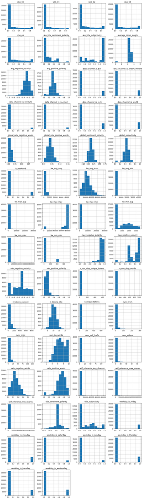

```python
# Histograms for each attribute
X_original.hist(layout=(dispRow,dispCol))
plt.show()
```

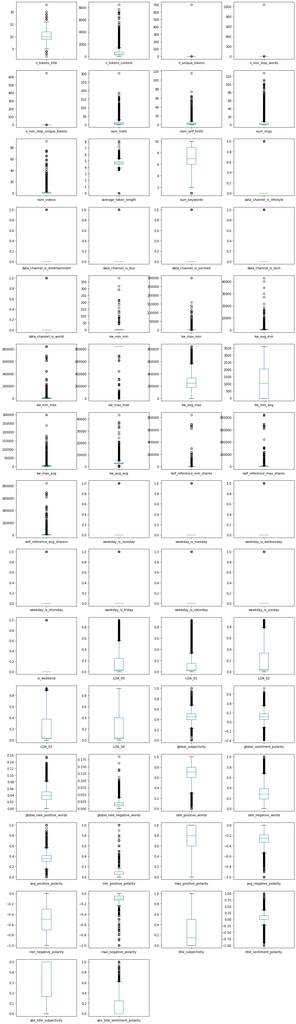

```python
# Box and Whisker plot for each attribute
X_original.plot(kind='box', subplots=True, layout=(dispRow,dispCol))
plt.show()
```

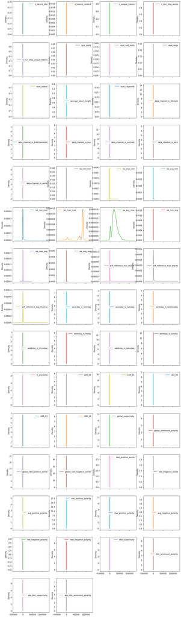

```python
# Density plot for each attribute
X_original.plot(kind='density', subplots=True, layout=(dispRow,dispCol))
plt.show()
```

#### 2.b.ii) Multivariate plots to better understand the relationships between attributes

```python
# Scatterplot matrix
# scatter_matrix(X_original)
# plt.show()
```

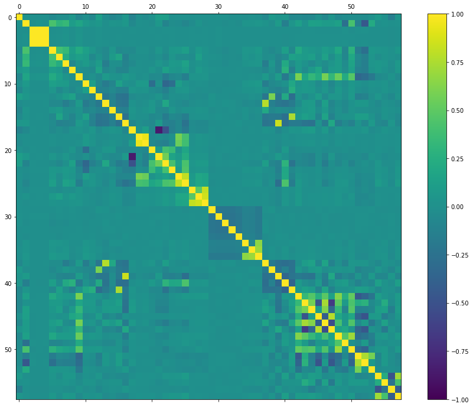

```python
# Correlation matrix
fig = plt.figure(figsize=(16,12))
ax = fig.add_subplot(111)
correlations = X_original.corr(method='pearson')
cax = ax.matshow(correlations, vmin=-1, vmax=1)
fig.colorbar(cax)
plt.show()
```

```python
if (notifyStatus): email_notify("Data Summarization and Visualization completed! "+datetime.now().strftime('%a %B %d, %Y %I:%M:%S %p'))
```

## Section 3 - Prepare Data

Some dataset may require additional preparation activities that will best exposes the structure of the problem and the relationships between the input attributes and the output variable. Some data-prep tasks might include:

- Cleaning data by removing duplicates, marking missing values and even imputing missing values.
- Feature selection where redundant features may be removed.
- Data transforms where attributes are scaled or redistributed in order to best expose the structure of the problem later to learning algorithms.

```python
if (notifyStatus): email_notify("Data Cleaning and Transformation has begun! "+datetime.now().strftime('%a %B %d, %Y %I:%M:%S %p'))
```

### 3.a) Feature Scaling and Data Pre-Processing

```python
tobe_transformed_cols = X_original.columns.tolist()
tobe_transformed_cols.remove('data_channel_is_lifestyle')
tobe_transformed_cols.remove('data_channel_is_entertainment')
tobe_transformed_cols.remove('data_channel_is_bus')
tobe_transformed_cols.remove('data_channel_is_socmed')
tobe_transformed_cols.remove('data_channel_is_tech')
tobe_transformed_cols.remove('data_channel_is_world')
tobe_transformed_cols.remove('weekday_is_monday')
tobe_transformed_cols.remove('weekday_is_tuesday')
tobe_transformed_cols.remove('weekday_is_wednesday')
tobe_transformed_cols.remove('weekday_is_thursday')
tobe_transformed_cols.remove('weekday_is_friday')
tobe_transformed_cols.remove('weekday_is_saturday')
tobe_transformed_cols.remove('weekday_is_sunday')
tobe_transformed_cols.remove('is_weekend')
print(tobe_transformed_cols)
```

[output not shown]

```python
# Apply feature scaling techniques
# X_original = X_original.astype(float)
scaler = preprocessing.StandardScaler()
X_original[tobe_transformed_cols] = scaler.fit_transform(X_original[tobe_transformed_cols])

X_original.head(-10)
```

|  | n_tokens_title | n_tokens_content | n_unique_tokens | n_non_stop_words | n_non_stop_unique_tokens | num_hrefs | num_self_hrefs | num_imgs | num_videos | average_token_length | ... | avg_positive_polarity | min_positive_polarity | max_positive_polarity | avg_negative_polarity | min_negative_polarity | max_negative_polarity | title_subjectivity | title_sentiment_polarity | abs_title_subjectivity | abs_title_sentiment_polarity |
| --- | --- | --- | --- | --- | --- | --- | --- | --- | --- | --- | --- | --- | --- | --- | --- | --- | --- | --- | --- | --- | --- |
| 0 | 0.757447 | -0.695210 | 0.032772 | 0.000675 | 0.038658 | -0.607463 | -0.335566 | -0.426526 | -0.304268 | 0.156474 | ... | 0.237337 | 0.063865 | -0.228941 | -0.708369 | -0.268895 | -0.969886 | 0.671245 | -0.975432 | -1.810719 | 0.138920 |
| 1 | -0.661657 | -0.618794 | 0.016056 | 0.000675 | 0.031479 | -0.695709 | -0.594963 | -0.426526 | -0.304268 | 0.432838 | ... | -0.640040 | -0.870968 | -0.228941 | 1.102174 | 1.367424 | 0.078642 | -0.870807 | -0.269076 | 0.837749 | -0.689658 |
| 2 | -0.661657 | -0.712192 | 0.007645 | 0.000675 | -0.007752 | -0.695709 | -0.594963 | -0.426526 | -0.304268 | -0.183415 | ... | 1.358401 | 0.063865 | 0.981798 | -1.621797 | -0.957871 | -0.270867 | -0.870807 | -0.269076 | 0.837749 | -0.689658 |
| 3 | -0.661657 | -0.032933 | -0.012619 | 0.000675 | -0.007211 | -0.166229 | -0.854360 | -0.426526 | -0.304268 | -0.169758 | ... | 0.307442 | 0.573773 | 0.174639 | -0.862584 | -0.268895 | -0.620377 | -0.870807 | -0.269076 | 0.837749 | -0.689658 |
| 4 | 1.230482 | 1.115439 | -0.037655 | 0.000675 | -0.045420 | 0.716237 | 4.074185 | 1.860061 | -0.304268 | 0.159400 | ... | 0.548135 | -0.870968 | 0.981798 | 0.307944 | 0.075594 | 0.602906 | 0.531059 | 0.244637 | -1.569949 | -0.087056 |
| ... | ... | ... | ... | ... | ... | ... | ... | ... | ... | ... | ... | ... | ... | ... | ... | ... | ... | ... | ... | ... | ... |
| 39629 | 1.230482 | -0.716437 | 0.030860 | 0.000675 | 0.010246 | -0.607463 | -0.594963 | -0.546872 | 0.182610 | 0.365019 | ... | 1.398258 | 1.466113 | 0.376429 | -0.838859 | 0.075594 | 0.078642 | 2.213297 | -2.152692 | 0.837749 | 1.519883 |
| 39630 | 0.757447 | -0.117840 | -0.026713 | 0.000675 | -0.024354 | -0.783956 | -0.335566 | -0.306179 | -0.060829 | -0.584146 | ... | -0.905937 | -0.461978 | 0.578218 | 0.740997 | 0.649740 | 0.602906 | 0.601152 | 0.364504 | -1.690334 | 0.053551 |
| 39631 | 1.230482 | 0.423444 | -0.023549 | 0.000675 | 0.014296 | -0.607463 | -0.594963 | -0.426526 | -0.304268 | -0.196829 | ... | 0.528042 | 0.063865 | 0.376429 | -0.904104 | -1.646847 | 0.602906 | 2.213297 | -4.036308 | 0.837749 | 3.729424 |
| 39632 | 2.176551 | 0.071079 | -0.011917 | 0.000675 | -0.008357 | 0.363251 | -0.335566 | -0.185832 | -0.304268 | 0.541137 | ... | 0.511842 | 0.063865 | 0.174639 | 1.131534 | 1.367424 | 0.078642 | 0.671245 | 1.614540 | -1.810719 | 1.519883 |
| 39633 | -0.661657 | 0.143250 | -0.020503 | 0.000675 | -0.022724 | -0.077983 | -0.854360 | -0.426526 | -0.304268 | 0.646881 | ... | 0.436022 | -0.637259 | 0.174639 | 0.612343 | 0.764570 | 0.602906 | -0.870807 | -0.269076 | 0.837749 | -0.689658 |

39634 rows × 58 columns

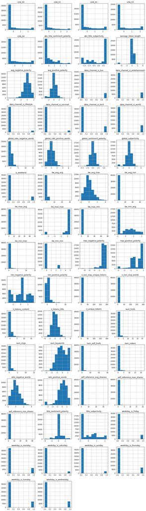

```python
# Histograms for each attribute
X_original.hist(layout=(dispRow,dispCol))
plt.show()
```

### 3.b) Splitting Data into Training and Test Sets

```python
# Split the data further into training and test datasets
if (splitDataset):
    X_train_df, X_test_df, y_train_df, y_test_df = train_test_split(X_original, y_original, test_size=splitPercentage, random_state=seedNum)
else:
    X_train_df, y_train_df = X_original, y_original
    X_test_df, y_test_df = X_original, y_original
print("X_train_df.shape: {} y_train_df.shape: {}".format(X_train_df.shape, y_train_df.shape))
print("X_test_df.shape: {} y_test_df.shape: {}".format(X_test_df.shape, y_test_df.shape))
```

```
X_train_df.shape: (29733, 58) y_train_df.shape: (29733,)
X_test_df.shape: (9911, 58) y_test_df.shape: (9911,)
```

### 3.c) Feature Selection

```python
# Not applicable for this iteration of the project
```

### 3.d) Display the Final Datasets for Model-Building

```python
# Finalize the training and testing datasets for the modeling activities
X_train = X_train_df.to_numpy()
y_train = y_train_df.to_numpy()
X_test = X_test_df.to_numpy()
y_test = y_test_df.to_numpy()
print("X_train.shape: {} y_train.shape: {}".format(X_train.shape, y_train.shape))
print("X_test.shape: {} y_test.shape: {}".format(X_test.shape, y_test.shape))
```

```
X_train.shape: (29733, 58) y_train.shape: (29733,)
X_test.shape: (9911, 58) y_test.shape: (9911,)
```

```python
if (notifyStatus): email_notify("Data Cleaning and Transformation completed! "+datetime.now().strftime('%a %B %d, %Y %I:%M:%S %p'))
```

## 4. Model and Evaluate Algorithms

After the data-prep, we next work on finding a workable model by evaluating a subset of machine learning algorithms that are good at exploiting the structure of the training. The typical evaluation tasks include:

- Defining test options such as cross validation and the evaluation metric to use.
- Spot checking a suite of linear and nonlinear machine learning algorithms.
- Comparing the estimated accuracy of algorithms.

Linear Algorithms: Linear Regression, Ridge Regression, LASSO Regression, and Elastic Net Regression

Non-Linear Algorithms: Decision Trees (CART) and k-Nearest Neighbors

Ensemble Algorithms: Random Forest, Extra Trees, and Gradient Boosting

The random number seed is reset before each run to ensure that the evaluation of each algorithm is performed using the same data splits. It ensures the results are directly comparable.

### 4.a) Set test options and evaluation metric

```python
# Set up Algorithms Spot-Checking Array
startTimeModule = datetime.now()
train_models = []
train_results = []
train_model_names = []
train_metrics = []
# train_models.append(('LNR', LinearRegression(n_jobs=n_jobs)))
# train_models.append(('RDG', Ridge(random_state=seedNum)))
# train_models.append(('LSO', Lasso(random_state=seedNum)))
train_models.append(('ELN', ElasticNet(random_state=seedNum)))
train_models.append(('CART', DecisionTreeRegressor(random_state=seedNum)))
train_models.append(('KNN', KNeighborsRegressor(n_jobs=n_jobs)))
train_models.append(('RNF', RandomForestRegressor(random_state=seedNum, n_jobs=n_jobs)))
train_models.append(('EXT', ExtraTreesRegressor(random_state=seedNum, n_jobs=n_jobs)))
# train_models.append(('GBM', GradientBoostingRegressor(random_state=seedNum)))
train_models.append(('XGB', XGBRegressor(objective='reg:squarederror', random_state=seedNum, n_jobs=n_jobs)))
```

```python
# Generate model in turn
for name, model in train_models:
	if (notifyStatus): email_notify("Algorithm "+name+" modeling has begun! "+datetime.now().strftime('%a %B %d, %Y %I:%M:%S %p'))
	startTimeModule = datetime.now()
	kfold = KFold(n_splits=n_folds, random_state=seedNum)
	cv_results = cross_val_score(model, X_train, y_train, cv=kfold, scoring=scoring)
	train_results.append(cv_results)
	train_model_names.append(name)
	train_metrics.append(cv_results.mean())
	print("%s: %f (%f)" % (name, cv_results.mean(), cv_results.std()))
	print(model)
	print ('Model training time:', (datetime.now() - startTimeModule), '\n')
	if (notifyStatus): email_notify("Algorithm "+name+" modeling completed! "+datetime.now().strftime('%a %B %d, %Y %I:%M:%S %p'))
print ('Average metrics ('+scoring+') from all models:',np.mean(train_metrics))
print ('Average RMSE for all models is:', math.sqrt((np.mean(train_metrics)*-1)))
print ('Total training time for all models:',(datetime.now() - startTimeModule))
```

```
ELN: -121399100.651983 (67418713.799704)
ElasticNet(alpha=1.0, copy_X=True, fit_intercept=True, l1_ratio=0.5,
           max_iter=1000, normalize=False, positive=False, precompute=False,
           random_state=888, selection='cyclic', tol=0.0001, warm_start=False)
Model training time: 0:00:02.168253

CART: -273788555.302479 (68373840.962023)
DecisionTreeRegressor(criterion='mse', max_depth=None, max_features=None,
                      max_leaf_nodes=None, min_impurity_decrease=0.0,
                      min_impurity_split=None, min_samples_leaf=1,
                      min_samples_split=2, min_weight_fraction_leaf=0.0,
                      presort=False, random_state=888, splitter='best')
Model training time: 0:00:46.341327

KNN: -138342849.914291 (65073870.524712)
KNeighborsRegressor(algorithm='auto', leaf_size=30, metric='minkowski',
                    metric_params=None, n_jobs=-1, n_neighbors=5, p=2,
                    weights='uniform')
Model training time: 0:01:20.426597

RNF: -149560786.706447 (71363871.718274)
RandomForestRegressor(bootstrap=True, criterion='mse', max_depth=None,
                      max_features='auto', max_leaf_nodes=None,
                      min_impurity_decrease=0.0, min_impurity_split=None,
                      min_samples_leaf=1, min_samples_split=2,
                      min_weight_fraction_leaf=0.0, n_estimators='warn',
                      n_jobs=-1, oob_score=False, random_state=888, verbose=0,
                      warm_start=False)
Model training time: 0:01:14.640794

EXT: -147178167.283383 (63948722.619404)
ExtraTreesRegressor(bootstrap=False, criterion='mse', max_depth=None,
                    max_features='auto', max_leaf_nodes=None,
                    min_impurity_decrease=0.0, min_impurity_split=None,
                    min_samples_leaf=1, min_samples_split=2,
                    min_weight_fraction_leaf=0.0, n_estimators='warn',
                    n_jobs=-1, oob_score=False, random_state=888, verbose=0,
                    warm_start=False)
Model training time: 0:00:48.509904

XGB: -129170056.638235 (71615807.349193)
XGBRegressor(base_score=0.5, booster='gbtree', colsample_bylevel=1,
             colsample_bynode=1, colsample_bytree=1, gamma=0,
             importance_type='gain', learning_rate=0.1, max_delta_step=0,
             max_depth=3, min_child_weight=1, missing=None, n_estimators=100,
             n_jobs=-1, nthread=None, objective='reg:squarederror',
             random_state=888, reg_alpha=0, reg_lambda=1, scale_pos_weight=1,
             seed=None, silent=None, subsample=1, verbosity=1)
Model training time: 0:00:34.340109

Average metrics (neg_mean_squared_error) from all models: -159906586.08280316
Average RMSE for all models is: 12645.417592266504
Total training time for all models: 0:00:34.344820
```

### 4.b) Spot-checking baseline algorithms

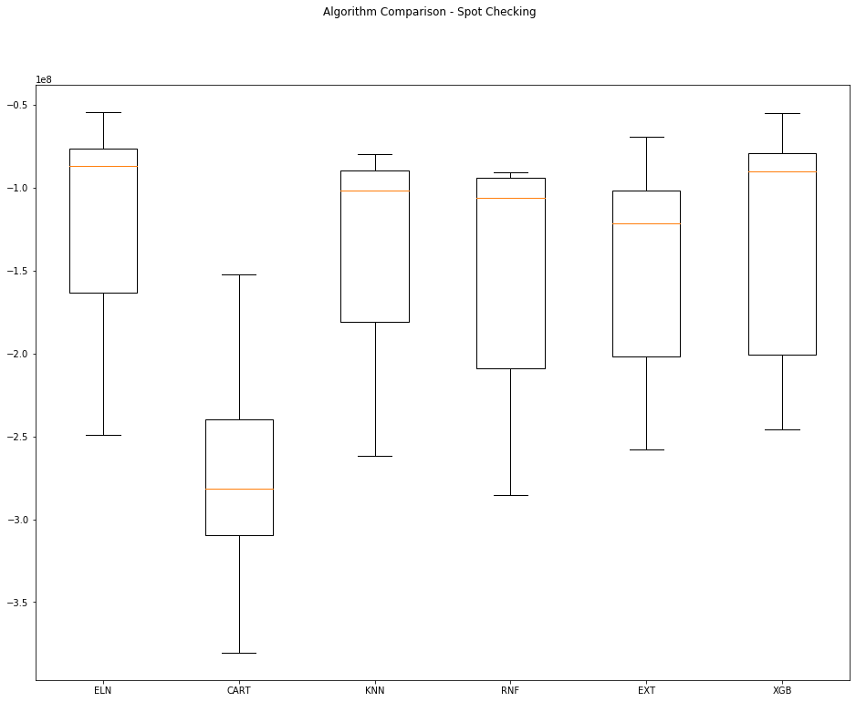

```python
fig = plt.figure(figsize=(16,12))
fig.suptitle('Algorithm Comparison - Spot Checking')
ax = fig.add_subplot(111)
plt.boxplot(train_results)
ax.set_xticklabels(train_model_names)
plt.show()
```

## Section 5 - Improve Accuracy

After we achieve a short list of machine learning algorithms with good level of accuracy, we can leverage ways to improve the accuracy of the models.

### 5.a) Algorithm Tuning

```python
# Set up the comparison array
tune_results = []
tune_model_names = []
```

```python
# Tuning algorithm #1 - Extra Trees
startTimeModule = datetime.now()
if (notifyStatus): email_notify("Algorithm #1 tuning has begun! "+datetime.now().strftime('%a %B %d, %Y %I:%M:%S %p'))

tune_model1 = ElasticNet(random_state=seedNum)
paramGrid1 = dict(alpha=np.array([0.25, 0.5, 1.0, 1.25, 1.5]))
tune_model_names.append('ET')

kfold = KFold(n_splits=n_folds, random_state=seedNum)
grid1 = GridSearchCV(estimator=tune_model1, param_grid=paramGrid1, scoring=scoring, cv=kfold)
grid_result1 = grid1.fit(X_train, y_train)

print("Best: %f using %s" % (grid_result1.best_score_, grid_result1.best_params_))
tune_results.append(grid_result1.cv_results_['mean_test_score'])
means = grid_result1.cv_results_['mean_test_score']
stds = grid_result1.cv_results_['std_test_score']
params = grid_result1.cv_results_['params']
for mean, stdev, param in zip(means, stds, params):
    print("%f (%f) with: %r" % (mean, stdev, param))
print ('Best RMSE for the Model is:', math.sqrt((grid_result1.best_score_*-1)))
print ('Model training time:',(datetime.now() - startTimeModule))
if (notifyStatus): email_notify("Algorithm #1 tuning completed! "+datetime.now().strftime('%a %B %d, %Y %I:%M:%S %p'))
```

```
Best: -121196278.372917 using {'alpha': 0.25}
-121196278.372917 (67435077.646248) with: {'alpha': 0.25}
-121283386.055214 (67418191.302002) with: {'alpha': 0.5}
-121394062.968119 (67417230.246159) with: {'alpha': 1.0}
-121438291.679304 (67419837.214728) with: {'alpha': 1.25}
-121478992.677224 (67423240.808763) with: {'alpha': 1.5}
Best RMSE for the Model is: 11008.91812908594
Model training time: 0:00:14.094818
```

```python
for key, value in grid_result1.best_params_.items():
    best_paramKey1 = key
    best_paramValue1 = value
print("Captured the best parameter for algorithm #1:", best_paramKey1, '=', best_paramValue1)
```

```
Captured the best parameter for algorithm #1: alpha = 0.25
```

```python
# Tuning algorithm #2 - Gradient Boosting
startTimeModule = datetime.now()
if (notifyStatus): email_notify("Algorithm #2 tuning has begun! "+datetime.now().strftime('%a %B %d, %Y %I:%M:%S %p'))

tune_model_names.append('XGB')
tune_model2 = XGBRegressor(objective='reg:squarederror', random_state=seedNum, n_jobs=n_jobs)
paramGrid2 = dict(n_estimators=np.array([10, 25, 50, 75, 100]))

kfold = KFold(n_splits=n_folds, random_state=seedNum)
grid2 = GridSearchCV(estimator=tune_model2, param_grid=paramGrid2, scoring=scoring, cv=kfold)
grid_result2 = grid2.fit(X_train, y_train)

print("Best: %f using %s" % (grid_result2.best_score_, grid_result2.best_params_))
tune_results.append(grid_result2.cv_results_['mean_test_score'])
means = grid_result2.cv_results_['mean_test_score']
stds = grid_result2.cv_results_['std_test_score']
params = grid_result2.cv_results_['params']
for mean, stdev, param in zip(means, stds, params):
    print("%f (%f) with: %r" % (mean, stdev, param))
print ('Best RMSE for the Model is:', math.sqrt((grid_result2.best_score_*-1)))
print ('Model training time:',(datetime.now() - startTimeModule))
if (notifyStatus): email_notify("Algorithm #2 tuning completed! "+datetime.now().strftime('%a %B %d, %Y %I:%M:%S %p'))
```

```
Best: -124546731.843451 using {'n_estimators': 10}
-124546731.843451 (68634357.363808) with: {'n_estimators': 10}
-126517325.473131 (69821620.092336) with: {'n_estimators': 25}
-128320080.690468 (71816894.914496) with: {'n_estimators': 50}
-128878867.146988 (71799968.427681) with: {'n_estimators': 75}
-129164862.282419 (71614065.467961) with: {'n_estimators': 100}
Best RMSE for the Model is: 11160.05070971681
Model training time: 0:01:28.087620
```

```python
for key, value in grid_result2.best_params_.items():
    best_paramKey2 = key
    best_paramValue2 = value
print("Captured the best parameter for algorithm #2:", best_paramKey2, '=', best_paramValue2)
```

```
Captured the best parameter for algorithm #2: n_estimators = 10
```

### 5.b) Compare Algorithms After Tuning

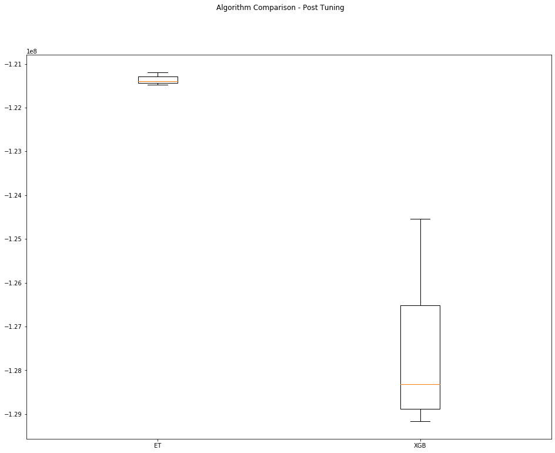

```python
fig = plt.figure(figsize=(16,12))
fig.suptitle('Algorithm Comparison - Post Tuning')
ax = fig.add_subplot(111)
plt.boxplot(tune_results)
ax.set_xticklabels(tune_model_names)
plt.show()
```

## Section 6 - Finalize Model

Once we have narrow down to a model that we believe can make accurate predictions on unseen data, we are ready to finalize it. Finalizing a model may involve sub-tasks such as:

- Using an optimal model tuned to make predictions on unseen data.
- Creating a standalone model using the tuned parameters
- Saving an optimal model to file for later use.

```python
if (notifyStatus): email_notify("Model Validation and Final Model Creation has begun! "+datetime.now().strftime('%a %B %d, %Y %I:%M:%S %p'))
```

### 6.a) Measure predictions from the test dataset

```python
test_model1 = ElasticNet(alpha=best_paramValue1, random_state=seedNum)
test_model1.fit(X_train, y_train)
predictions1 = test_model1.predict(X_test)
print('RMSE for the model is: ', math.sqrt(mean_squared_error(y_test, predictions1)))
print('R2 for the model is: ', r2_score(y_test, predictions1))
print(test_model1)
```

```
RMSE for the model is:  12947.649233036378
R2 for the model is:  0.012956867623891144
ElasticNet(alpha=0.25, copy_X=True, fit_intercept=True, l1_ratio=0.5,
           max_iter=1000, normalize=False, positive=False, precompute=False,
           random_state=888, selection='cyclic', tol=0.0001, warm_start=False)
```

```python
test_model2 = XGBRegressor(n_estimators=best_paramValue2, objective='reg:squarederror', random_state=seedNum, n_jobs=n_jobs)
test_model2.fit(X_train, y_train)
predictions2 = test_model2.predict(X_test)
print('RMSE for the model is: ', math.sqrt(mean_squared_error(y_test, predictions2)))
print('R2 for the model is: ', r2_score(y_test, predictions2))
print(test_model2)
```

```
RMSE for the model is:  13071.697268463833
R2 for the model is:  -0.006046936953923776
XGBRegressor(base_score=0.5, booster='gbtree', colsample_bylevel=1,
             colsample_bynode=1, colsample_bytree=1, gamma=0,
             importance_type='gain', learning_rate=0.1, max_delta_step=0,
             max_depth=3, min_child_weight=1, missing=None, n_estimators=10,
             n_jobs=-1, nthread=None, objective='reg:squarederror',
             random_state=888, reg_alpha=0, reg_lambda=1, scale_pos_weight=1,
             seed=None, silent=None, subsample=1, verbosity=1)
```

### 6.b) Create a standalone model using all available data

```python
# Combining the training and testing datasets to form the complete dataset that will be used for training the final model
X_complete = np.vstack((X_train, X_test))
y_complete = np.concatenate((y_train, y_test))
print("X_complete.shape: {} y_complete.shape: {}".format(X_complete.shape, y_complete.shape))
finalModel = test_model1
```

```
X_complete.shape: (39644, 58) y_complete.shape: (39644,)
```

### 6.c) Save the final model for later use

```python
# modelName = 'finalModel_Regression.sav'
# dump(finalModel, modelName)
```

```python
if (notifyStatus): email_notify("Model Validation and Final Model Creation completed! "+datetime.now().strftime('%a %B %d, %Y %I:%M:%S %p'))
```

```python
print ('Total time for the script:',(datetime.now() - startTimeScript))
```

```
Total time for the script: 0:12:48.316694
```